# Classical and Bayesian Kriging applied - Rain dataset

Andrea Pisani

## Libraries

```r
library(geoR)
library(ggplot2)
library(mgcv)
library(spBayes)
library(MBA)
library(fields)
```

## Rain data

The “datipioggia” dataset contains the survey about the total annual rain expressed in millimeters, in the italian Hydrological Basin of Catanzaro (Comparto Idrologico di Catanzaro) in Italy. The data are registered from 1970 to 1982, but only 1978 and 1981 will be considered for the spatial analysis and the comparison.

The main goal of the statistical analysis is the prediction on unobserved locations in a grid covering the Basilicata and Calabria regions, meaning that we have to infer the total annual rain value for each point.

```r
### Import data 1978, 1981
load("datipioggia.RData")
load("quota32.RData")

### Structure of the dataset
str(dati)
```

```
## 'data.frame':    2373 obs. of  10 variables:
##  $ ID1         : int  1 2 3 4 5 6 7 8 9 10 ...
##  $ ID          : num  4071 4072 4075 4081 4085 ...
##  $ Nome_Regione: Factor w/ 3 levels "Basilicata","Calabria",..: 1 1 1 1 3 3 1 1 1 1 ...
##  $ Lat10       : num  40.7 40.7 40.9 40.6 40.8 ...
##  $ Lon10       : num  15.9 16 16 16.2 16.4 ...
##  $ YUTM        : num  4531697 4529037 4554393 4519994 4544054 ...
##  $ XUTM        : num  1083655 1092377 1087794 1105035 1125172 ...
##  $ Quota       : num  620 568 483 698 380 462 3 933 747 700 ...
##  $ anno        : num  1970 1970 1970 1970 1970 1970 1970 1970 1970 1970 ...
##  $ totanno     : num  589 588 546 524 531 ...
```

To develop a prediction the variables needed are Regione (region), YUTM, XUTM, Quota (the height), anno (year) and totanno. The last one contains the totalrain in mm measured in each observatory.

The coordinates are given in UTM (Universal Transverse Mercator) coordinate system, a projection that allows us to use the locations in a 2-dimensional Cartesian space, with no need to consider the earth curvature.

In the datasets “Cal” and “Bas” there are the points to draw the contour of the 2 regions considered in the analysis: Calabria and Basilicata.

```r
calabria = Cal[-1]/1000
colnames(calabria) = c("x", "y")

basilicata = Bas[-1]/1000
colnames(basilicata) = c("x", "y")
```

The grid of points to estimate in the 2 regions are in the Calabriaquota32 and Basquota32 databases. The analysis is performed considering kilometers instead of meters, to avoid computational problems (e.g. in the matrix inversion computed using Ordinary Kriging algorithm).

```r
### Grid
cal.grid = Calabriaquota32[,2:4]
cal.grid[,1:3] = cal.grid[,1:3]/1000
colnames(cal.grid) = c("x", "y", "z")

bas.grid = Basquota32[,2:4]
bas.grid[,1:3] = bas.grid[,1:3]/1000
colnames(bas.grid) = c("x", "y", "z")

### Merging the 2 grid
grid = rbind(cal.grid[1:3], bas.grid[1:3])
```

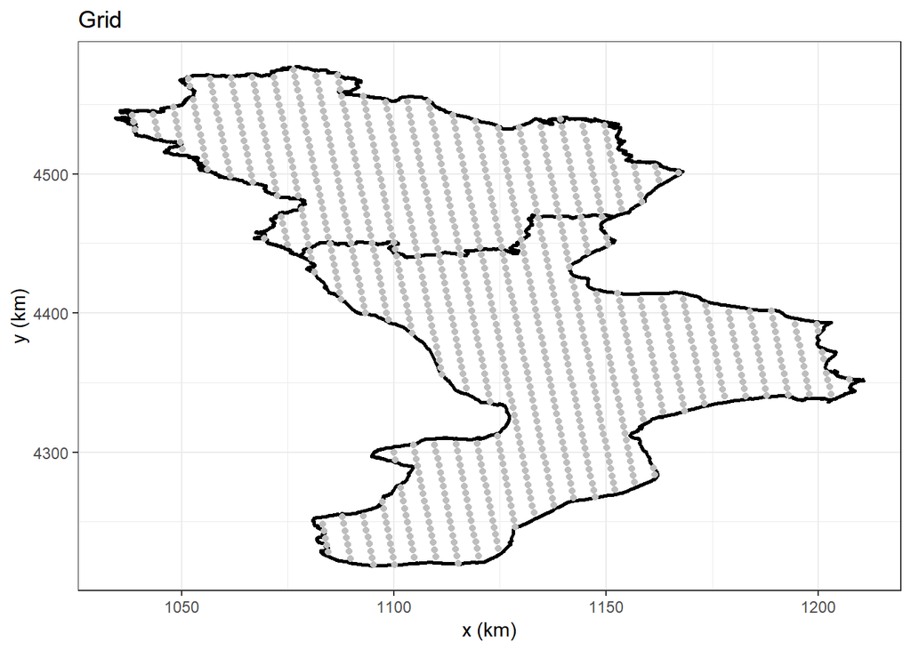

## Year 1978

The next R chunk contains the creation of the dataset relative to the year 1978, for the regions Basilicata and Calabria (Puglia region is not included). The spatial data are converted from meters to kilometers and the variables not needed are discarded.

```r
### dataset 1978
data.1978 = data.frame(dati$XUTM, dati$YUTM, dati$Quota,
                      dati$totanno, dati$anno, dati$Nome_Regione)
colnames(data.1978) = c("x", "y", "z", "value", "year", "regione")

### extracting rows for 1978, Puglia and Calabria
data.1978 = data.1978[which((data.1978[5]==1978) &
                      (data.1978[6]=="Basilicata" | data.1978[6] =="Calabria")),]

### deleting year and region columns, useless for the analysis
data.1978 = data.1978[-c(5,6)]
data.1978[,1:3] = data.1978[,1:3]/1000
row.names(data.1978) = NULL
str(data.1978)
```

```
## 'data.frame':    179 obs. of  4 variables:
##  $ x    : num  1084 1092 1088 1163 1084 ...
##  $ y    : num  4532 4529 4554 4497 4524 ...
##  $ z    : num  0.62 0.568 0.483 0.003 0.933 0.747 0.7 0.557 0.45 0.481 ...
##  $ value: num  456 615 623 415 806 ...
```

```r
### Creating Geodata
geo.data.1978 = as.geodata(obj=data.1978,
                           coords=c(1,2),
                           data.col=4,
                           covar.col=3,
                           covar.names=c("z"))
```

The evaluation of the points in the grid has to be done using the black points showed in the next plot.

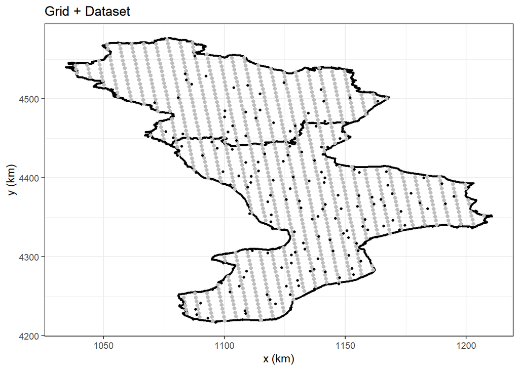

The next plot shows the spatial coordinates $x$ and $y$ of each point in the dataset while color and size are used to have a qualitative knowledge of the rain distribution in the regions.

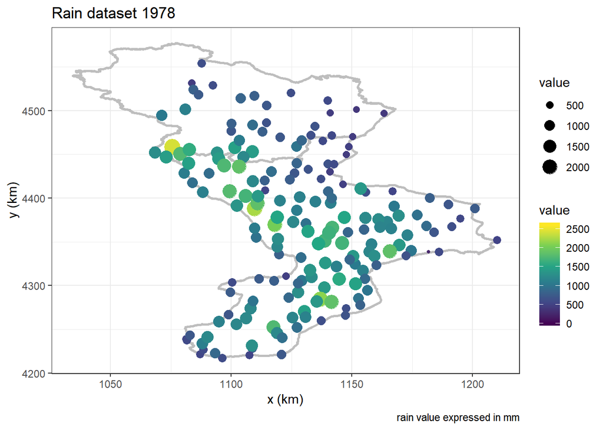

### The Model

This is the model we will use for the Kriging algorithm:

$$P(x,y,z) = \beta_0 + z \cdot \beta_1 + W(x,y) + \epsilon(x,y,z)$$

where $\beta_0 + z \cdot \beta_1$ is the deterministic part with respect to the height, $W(x,y)$ is the stationary spatial process and $\epsilon(x,y,z)$ is the measurement error.

### Normality Test

First of all, we need to check if the 1978 dataset has a normal distribution, because we are assuming that the spatial process is gaussian. We’ll use the Shapiro-Wilk test, which is robust for spatially dependent data, and the Q-Q plot.

```r
### Shapiro-Wilk Test
shapiro.test(data.1978$value)
```

```
##
##  Shapiro-Wilk normality test
##
## data:  data.1978$value
## W = 0.96223, p-value = 9.378e-05
```

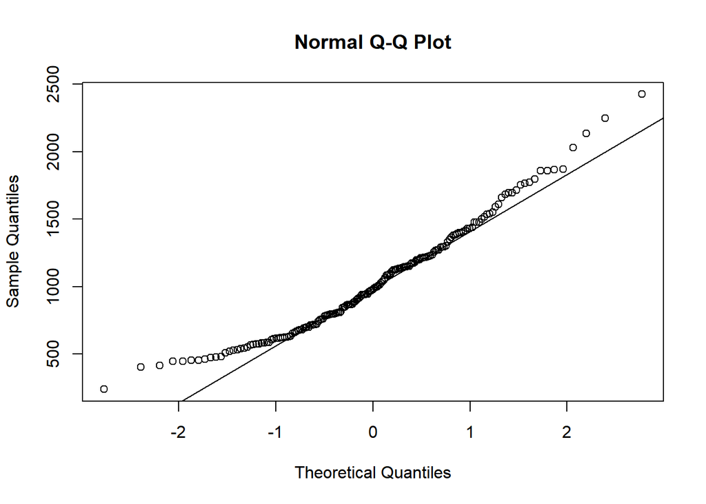

```r
qqnorm(data.1978$value)
qqline(data.1978$value)
```

The p-value is very low and also the Q-Q plot shows that the behaviour of our dataset is not really gaussian.

We perform the same analysis on the residuals of a simple linear regression model of the value (rain in mm) in the logarithmic scale with respect to the height.

The choice of the height in the regression comes from the physical process called orographic lift. This occurs when an air mass, with high concentration of moisture, is forced from a low elevation to a higher elevation as it moves over the rising terrain: the higher is the difference in altitude, the more the air mass quickly cools down adiabatically (without trasferring heat). This process raises the relative level of humidity and can create clouds and also precipitation.

The regions Calabria and Basilicata have the right elements for the orographic lift: a steep gap between the coast and the mountain.

```r
### Mean estimation
model1 = lm(log(value) ~ z, data = data.1978)
summary(model1)
```

```
##
## Call:
## lm(formula = log(value) ~ z, data = data.1978)
##
## Residuals:
##      Min       1Q   Median       3Q      Max
## -1.14875 -0.27024  0.01595  0.29604  0.92820
##
## Coefficients:
##             Estimate Std. Error t value Pr(>|t|)
## (Intercept)  6.62001    0.04511 146.745  < 2e-16 ***
## z            0.54640    0.08120   6.729 2.28e-10 ***
## ---
## Signif. codes:  0 '***' 0.001 '**' 0.01 '*' 0.05 '.' 0.1 ' ' 1
##
## Residual standard error: 0.3669 on 177 degrees of freedom
## Multiple R-squared:  0.2037, Adjusted R-squared:  0.1992
## F-statistic: 45.29 on 1 and 177 DF,  p-value: 2.279e-10
```

```r
rr1 = model1$residuals

### Shapiro-Wilk Test on residuals
shapiro.test(rr1)
```

```
##
##  Shapiro-Wilk normality test
##
## data:  rr1
## W = 0.98969, p-value = 0.2221
```

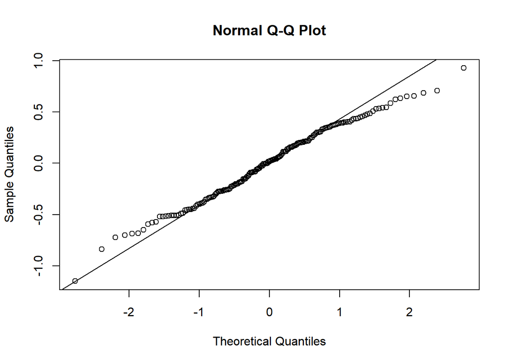

```r
qqnorm(rr1)
qqline(rr1)
```

As the Shapiro-WIlk test and the Q-Q plot show, the behaviour of the residuals is approximately normal.

## Ordinary Kriging 1978

The Ordinary Kriging method is a method of interpolation that uses a Gaussian process governed by a prior covariance. Each point of the grid in the Calabria and Basilicata regions will be evaluated computing a weighted average of the known values in the neighborhood of the point.

### Variogram

A covariance function is needed for the Ordinary Kriging algorithm: a variogram can help to find a simple structure.

The Variogram is a function that describes the spatial dependence of a stochastic process. It express the variation on samples with respect to the distance of those samples from each other.

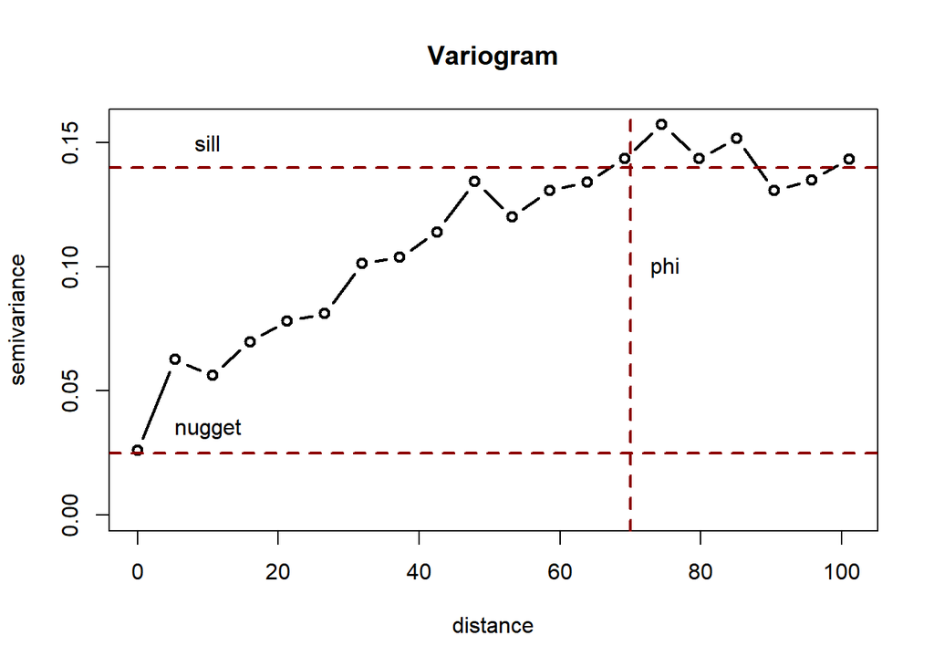

A first order trend on the height is used to estimate the log-mean of the process so the variogram will be computed only for the log of the residuals.

$$log(value) = \beta_0 + z \cdot \beta_1$$

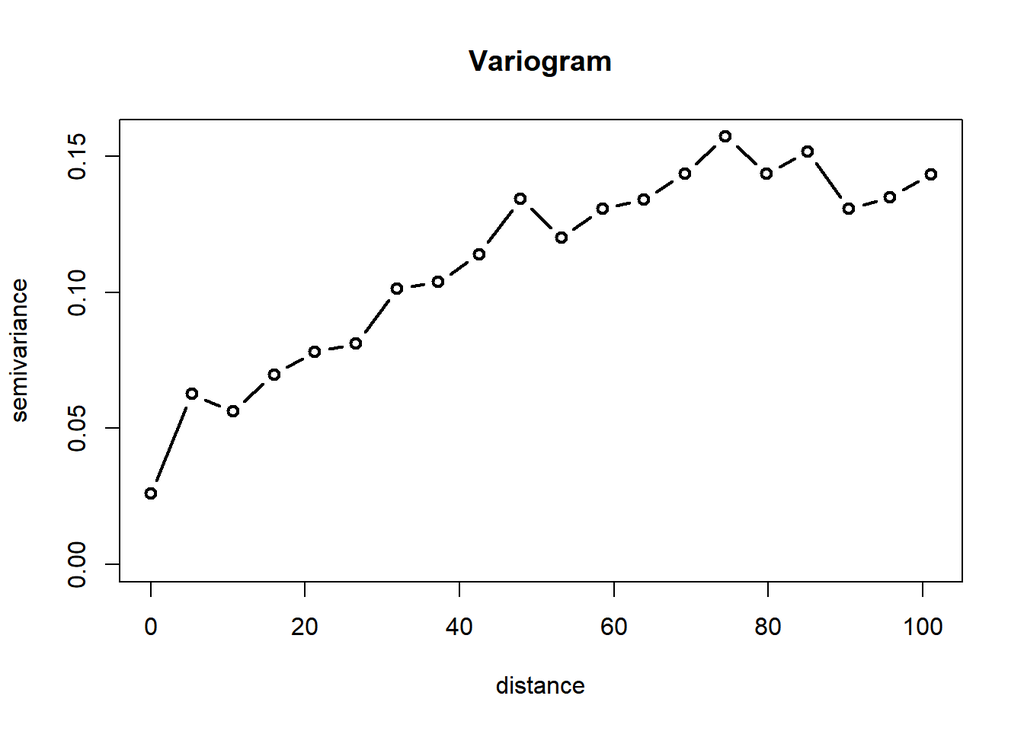

```r
### Variogram of the residuals
max.dist = max(dist(data.1978[,1:2]))
vv = variog(geo.data.1978,
            trend = ~geo.data.1978$covar$z,
            uvec=seq(0, 0.3*max.dist, length=20),
            lambda=0,
            messages=F)
vv4 = variog4(geo.data.1978,
             trend = ~geo.data.1978$covar$z,
             uvec=seq(0, 0.3*max.dist, length=20),
             lambda=0,
             messages=F)

plot(vv, type="b", lwd=2)
title("Variogram")
```

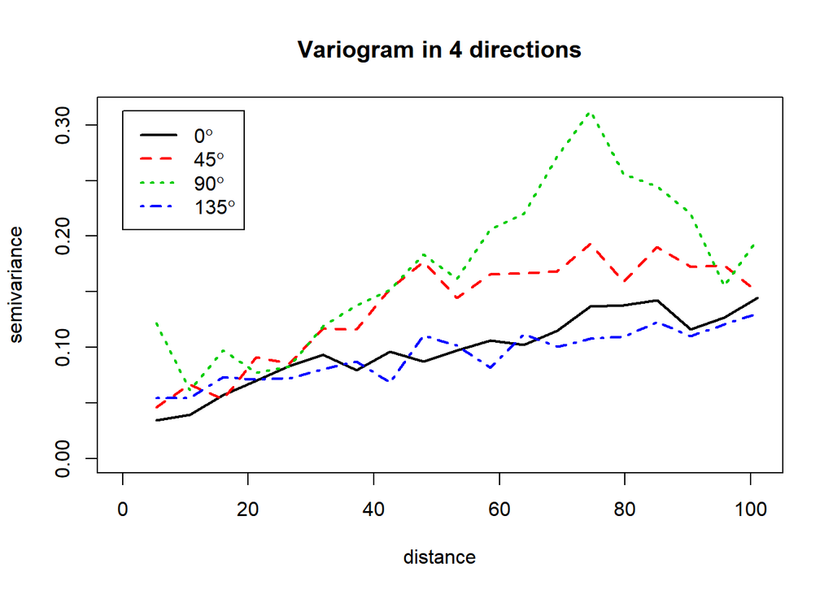

```r
plot(vv4, lwd=2)
title("Variogram in 4 directions")
```

#### Ordinary Kriging

The covariance function chosen is the spherical one. The parameters chosen by inspection of the variogram are plugged-in and a cross-validation coefficient is computed to check if the fit of the model with the dataset is good.

```r
### Fit of the covariance function
vv.model = likfit(geo.data.1978,
                  trend = ~geo.data.1978$covar$z,
                  ini.cov.pars=c(0.15, 100),
                  nugget=0.04,
                  cov.model="spherical",
                  messages=FALSE,
                  lambda=0)

CV.model = xvalid(geo.data.1978,
                  model=vv.model,
                  messages=FALSE)

### CV coefficient
mean(CV.model$std.error^2)
```

```
## [1] 0.8632041
```

```r
### Ordinary Kriging
out = output.control(quantile=c(0.025,0.5,0.975), messages=F)

krig.par <- krige.control(type.krige='ok',
                          cov.pars=vv.model$cov.pars,
                          nugget=vv.model$nugget,
                          trend.d=~geo.data.1978$covar$z,
                          trend.l=~grid[,3],
                          cov.model = "spherical",
                          lambda=0)

pred.okrig <- krige.conv(geo.data.1978,
                         locations=grid[,1:2],
                         krige=krig.par,
                         output=out)

### Kriging prediction dataset
pred.okrig.1978 = cbind(grid[,1:2],
                        pred.okrig$predict,
                        pred.okrig$quantiles.simulations$q2.5,
                        pred.okrig$quantiles.simulations$q50,
                        pred.okrig$quantiles.simulations$q97.5)

colnames(pred.okrig.1978) = c("x","y","value","lower","median","upper")
```

We can compare the values of the 1978 dataset with the ones obtain using the Ordinary Kriging algorithm, using both mean and median.

```r
### Data 1978
summary(data.1978$value)
```

```
##    Min. 1st Qu.  Median    Mean 3rd Qu.    Max.
##   240.1   701.3   980.9  1034.4  1271.6  2426.2
```

```r
### Ordinary Kriging prediction mean
summary(pred.okrig.1978$value)
```

```
##    Min. 1st Qu.  Median    Mean 3rd Qu.    Max.
##   425.0   680.2   935.6  1021.1  1295.4  2478.2
```

```r
### Ordinary Kriging prediction median
summary(pred.okrig.1978$median)
```

```
##    Min. 1st Qu.  Median    Mean 3rd Qu.    Max.
##   413.1   656.0   905.4   992.0  1262.9  2395.6
```

```
##    Min. 1st Qu.  Median    Mean 3rd Qu.    Max.
##   364.2   682.8   908.0   977.5  1212.5  2507.0
```

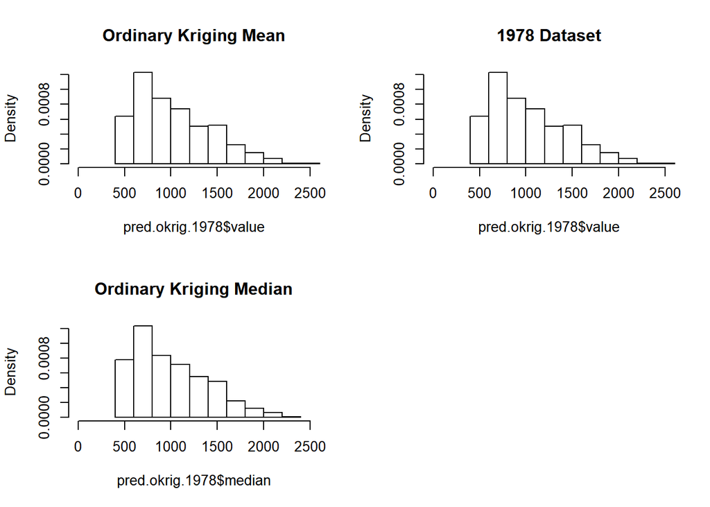

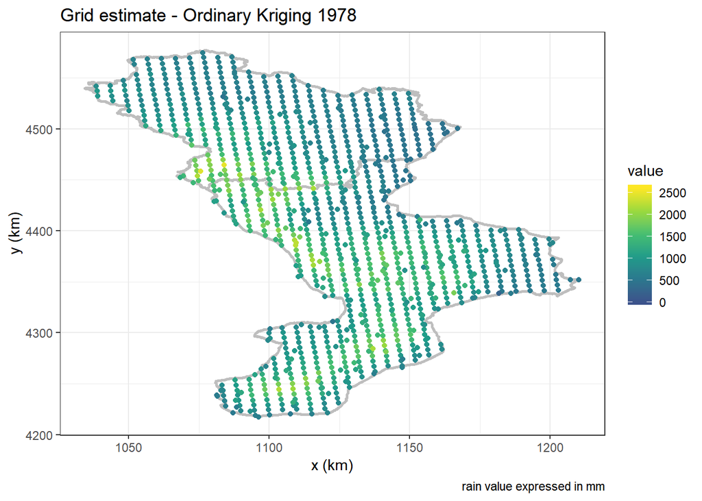

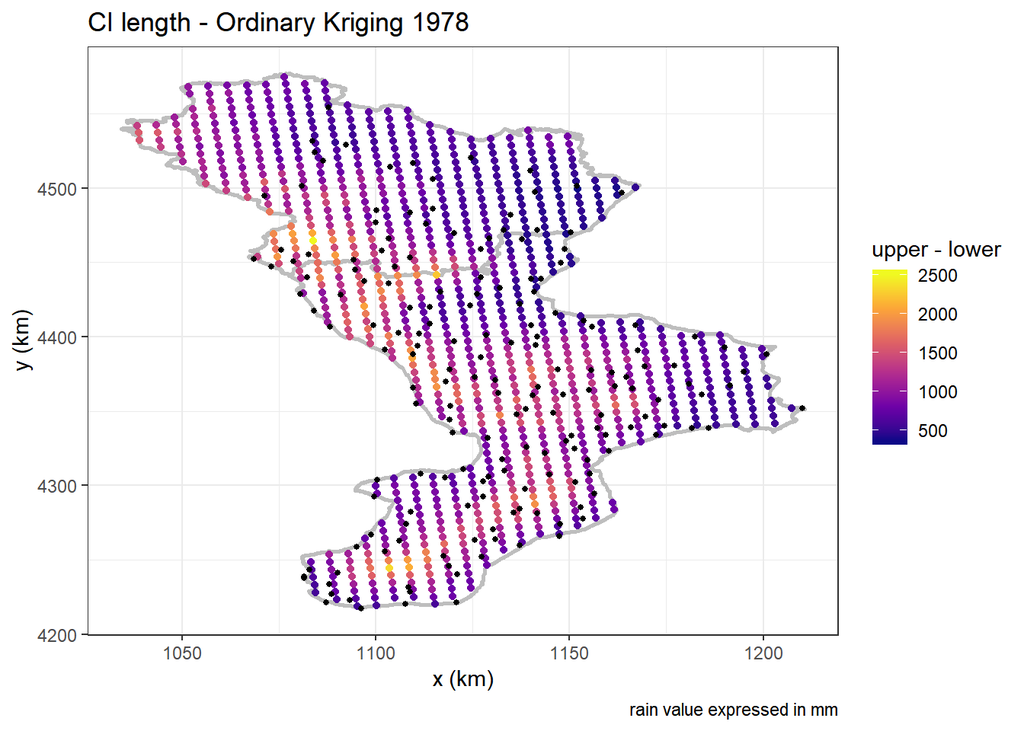

```r
par(mfrow=c(2,2))
hist(pred.okrig.1978$value, main="", xlim=c(0,2500), prob=T)
title("Ordinary Kriging Mean")
hist(pred.okrig.1978$value, main="", xlim=c(0,2500), prob=T)
title("1978 Dataset")
hist(pred.okrig.1978$median, main="", xlim=c(0,2500), prob=T)
title("Ordinary Kriging Median")

### 95% Confidence Interval Ordinary Kriging
difference.okrig = pred.okrig.1978$upper - pred.okrig.1978$lower
summary(difference.okrig)
```

### Residuals analysis

If we analyze the confidence interval in the log-scale, we notice that the uncertainty is higher where the concentration of points is lower.

```r
### Fit of the covariance function
vv.model = likfit(coords=data.1978[,1:2],
                  data=rr1,
                  ini.cov.par=c(0.15, 200),
                  nugget=0.06,
                  cov.model="spherical",
                  messages=FALSE)

CV.model = xvalid(coords=data.1978[,1:2],
                  data=rr1,
                  model=vv.model,
                  messages=FALSE)

### CV coefficient
mean(CV.model$std.error^2)
```

```
## [1] 0.9772441
```

```r
### Ordinary Kriging
krig.par <- krige.control(type.krige='ok',
                          cov.pars=vv.model$cov.pars,
                          nugget=vv.model$nugget,
                           cov.model = "spherical")

pred.okrig <- krige.conv(coords=data.1978[,1:2],
                         data=rr1,
                         locations=grid[,1:2],
                         krige=krig.par,
                         output=out)

### Kriging prediction dataset
rr.pred.okrig.1978 = cbind(grid[,1:2],
                        pred.okrig$predict,
                        pred.okrig$quantiles.simulations$q2.5,
                        pred.okrig$quantiles.simulations$q50,
                        pred.okrig$quantiles.simulations$q97.5)

colnames(rr.pred.okrig.1978) = c("x","y","value","lower","median","upper")
```

```r
### 95% Confidence Interval Ordinary Kriging
rr.difference.okrig = rr.pred.okrig.1978$upper - rr.pred.okrig.1978$lower
```

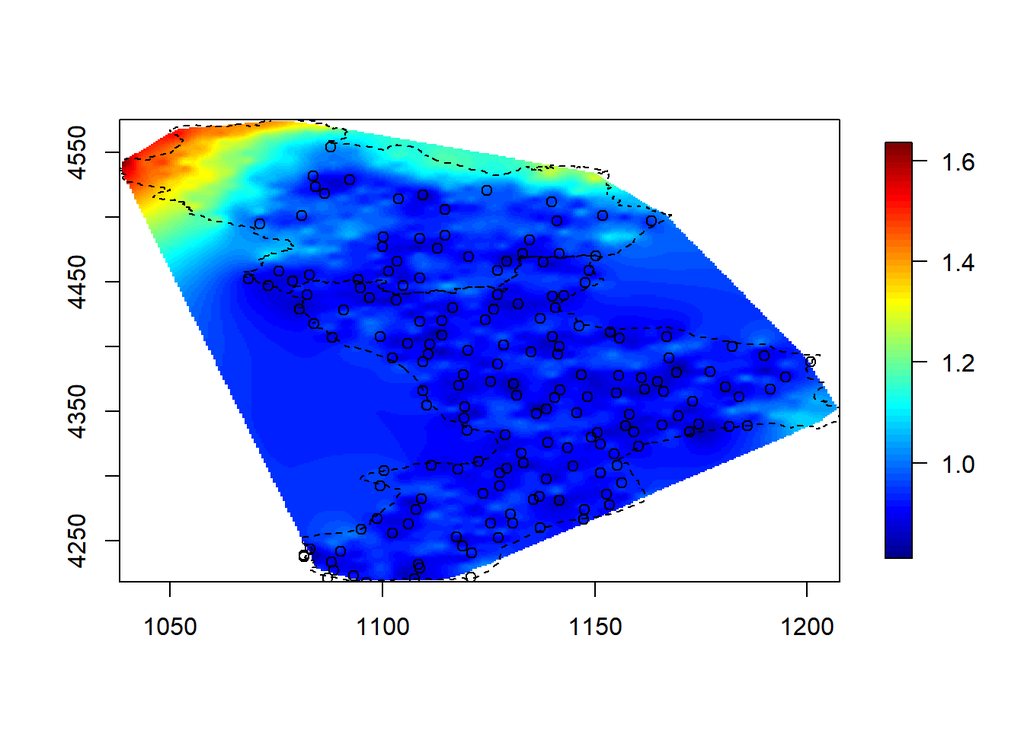

```r
surf <- mba.surf(cbind(grid[,1:2], rr.difference.okrig),
                 no.X=300, no.Y=300)$xyz.est
image.plot(surf, main="",
           horizontal=F)
lines(calabria, lty=2)
lines(basilicata, lty=2)
points(data.1978[,1],data.1978[,2])
```

The confidence intervals change if we go back in the original scale, because the variance of the log-normal distribution is higher where the mean has an high value.

If $\sigma_l^2$ and $\mu_l$ are the variance and the mean in the log-scale, in the original scale the variance will be:

$$\sigma ^2 = exp \big( \sigma_l^2 \big) \cdot exp
\big( 2 \mu_l + \sigma_l \big)$$

## Bayesian Kriging 1978

We can perform the Kriging using an approximated Bayesian approach, specifying different levels of uncertainty in the model parameters. The results will be the posterior distributions for the model parameters and the predictive distributions for the provided locations.

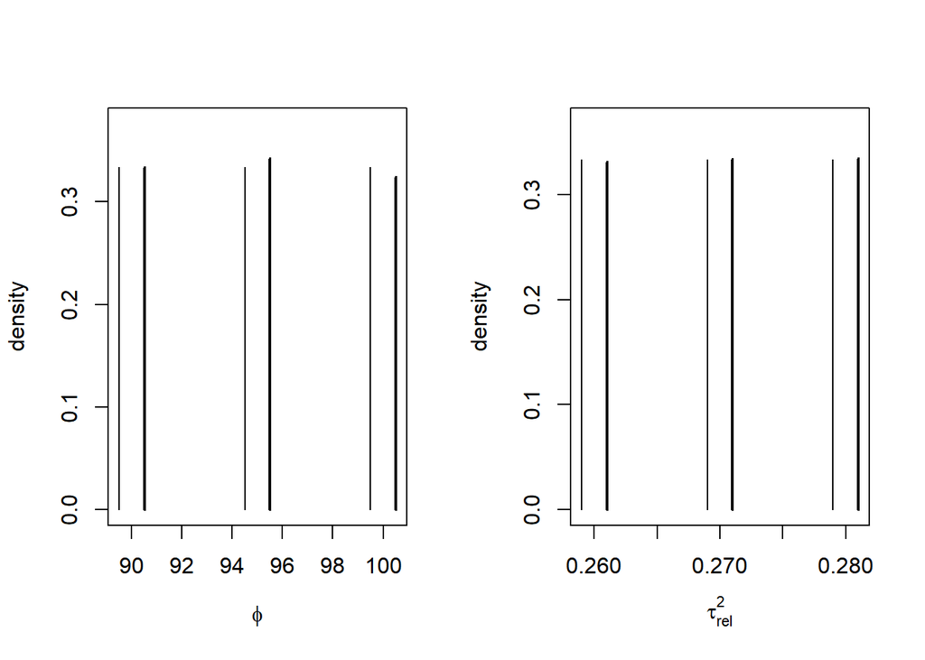

```r
### Covariance function
ctrl = model.control(trend.d=~geo.data.1978$covar$z,
                      trend.l=~grid[,3],
                      cov.model = "spherical",
                      lambda=0)

### Prior distribution for phi and tausq.rel
prior.list = prior.control(phi.prior = "uniform",
                         phi.discrete =seq(90,100,by=5),
                         tausq.rel.prior ="uniform",
                         tausq.rel.discrete = seq(0.26,0.28,by=0.01))

output=output.control(n.posterior=500,
                      messages=F)

### Bayesian Kriging
krig.b = krige.bayes(geo.data.1978,
                     model=ctrl,
                     prior=prior.list,
                     output=output)
par(mfrow=c(1,2))
plot(krig.b, type="h")
```

```r
### Bayes Kriging prediction
output=output.control(n.posterior=500, n.predictive=500,
                      messages=F, quantile=c(0.025,0.975))

krig.b=krige.bayes(geo.data.1978,
                   model=ctrl,
                   prior=prior.list,
                   output=output,
                   locations=grid[,1:2])
```

```r
pred.krigb.1978 = cbind(grid[,1:2],
                    krig.b$predictive$mean,
                    krig.b$predictive$quantiles.simulations$q2.5,
                    krig.b$predictive$quantiles.simulations$q97.5)
colnames(pred.krigb.1978) = c("x","y","value","lower", "upper")

### Data 1978 vs Bayesian Kriging prediction
summary(pred.krigb.1978$value)
```

```
##    Min. 1st Qu.  Median    Mean 3rd Qu.    Max.
##   417.4   664.0   917.4  1003.4  1274.8  2434.6
```

```r
summary(data.1978$value)
```

```
##    Min. 1st Qu.  Median    Mean 3rd Qu.    Max.
##   240.1   701.3   980.9  1034.4  1271.6  2426.2
```

```r
### 95% Confidence interval Bayesian Kriging
difference.bayes = pred.krigb.1978$upper - pred.krigb.1978$lower
summary(difference.bayes)
```

```
##    Min. 1st Qu.  Median    Mean 3rd Qu.    Max.
##   227.9   430.8   571.3   622.8   766.3  1636.5
```

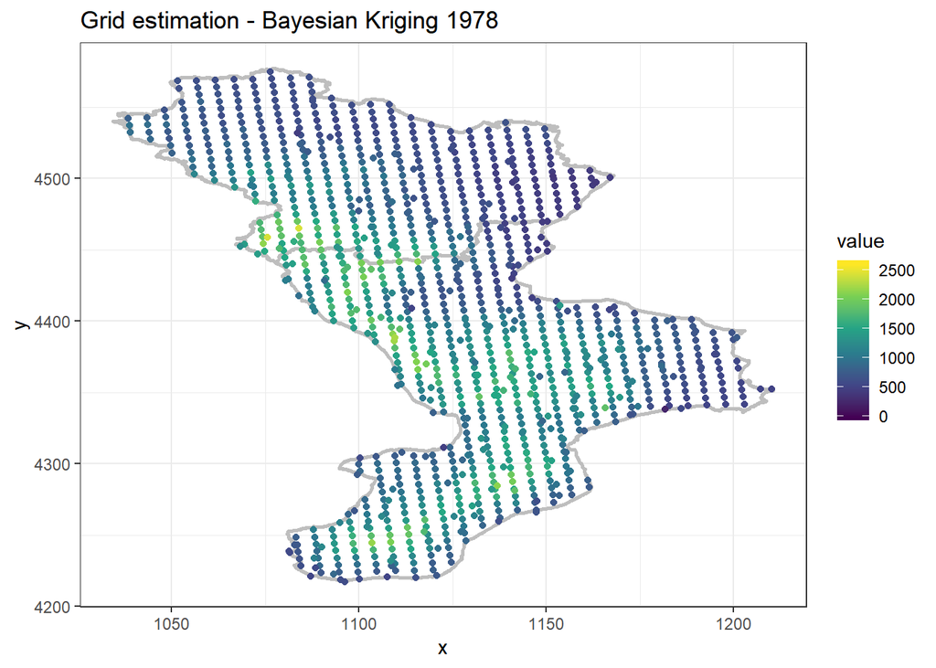

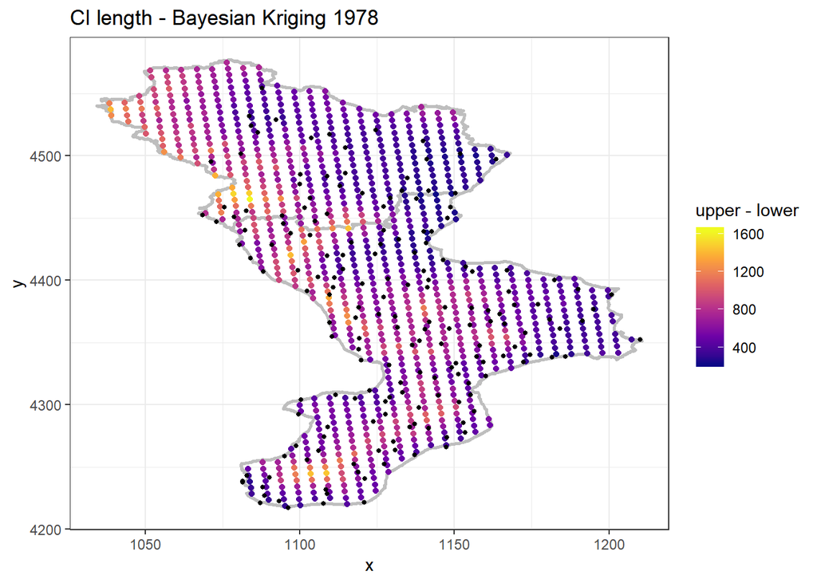

## Splm

Now we’ll use a Full Bayesian approach, without approximations.

As we did in the previous computations, we assume that each point is a realization of a gaussian process with mean $z \times \beta$, residuals $W(s)$ comprising a spatial process and normal independent white-noise $\epsilon(s)$, with $s \in R^3$ that captures measurement errors.

We assume second order stationarity in order to simplify the covariance structure and exploit the variogram to choose the parameters for the spLM function.

The spLM function works on the statistical setting that we just described and implement a MCMC algorithm. Given prior distributions for the covariance function, initial values and the hyperparameters, the output is the posterior distribution of those parameters. The sampling of the posterior is conducted exploiting Gibbs sampling and Metropolis algorithms, hence a proposal variance in the tuning option must be provided.

```r
n.samples = 60000
post.splm.1978 <- spLM(log(data.1978$value)~data.1978$z,
            coords=as.matrix(data.1978[,1:2]),
            starting=list("phi"=0.0105,
                          "sigma.sq"=0.15,
                          "tau.sq"=0.04),
            tuning=list("phi"=0.2, "sigma.sq"=0.1, "tau.sq"=0.01),
            priors=list("phi.unif"=c(0.01, 0.15),
                        "sigma.sq.IG"=c(2, 0.14),
                        "tau.sq.IG"=c(2, 0.04)),
            cov.model="spherical", n.samples=n.samples, verbose=F)

### Acceptance rate
mean(post.splm.1978$acceptance)
```

```
## [1] 50.28833
```

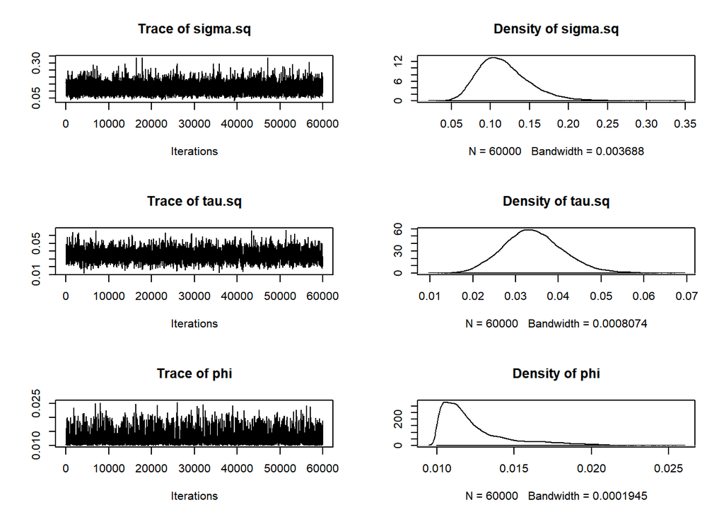

```r
### Traceplots and posterior distributions
plot(post.splm.1978$p.theta.samples)
```

The prediction chunk is not included in this presentation to avoid the output messages. The prediction is computed with a 15% burn-in and thinning equal to 10.

```r
### spLM prediction
pred.splm.1978 <- apply(exp(splm.1978$p.y.predictive.samples),
                        1, mean)

### quantile
quant = t(apply(exp(splm.1978$p.y.predictive.samples), 1, quantile,
            probs=c(0.025,0.975)))

pred.splm.1978 = data.frame(grid[,1:2],pred.splm.1978,quant)
colnames(pred.splm.1978) = c("x","y","value","lower","upper")

### Data 1978 vs spLM prediction
summary(data.1978$value)
```

```
##    Min. 1st Qu.  Median    Mean 3rd Qu.    Max.
##   240.1   701.3   980.9  1034.4  1271.6  2426.2
```

```r
summary(pred.splm.1978$value)
```

```
##    Min. 1st Qu.  Median    Mean 3rd Qu.    Max.
##   425.3   684.7   931.4  1024.2  1297.8  2506.7
```

```r
### 95% Confidence Interval spLM 1978
difference.splm = quant[,2]-quant[,1]
summary(difference.splm)
```

```
##    Min. 1st Qu.  Median    Mean 3rd Qu.    Max.
##   401.4   697.4   928.3   995.6  1235.2  2710.1
```

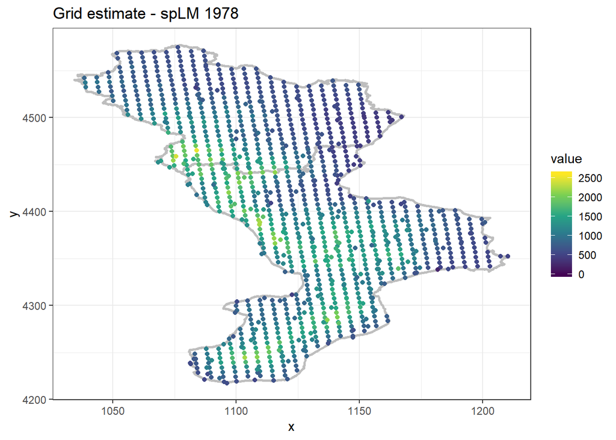

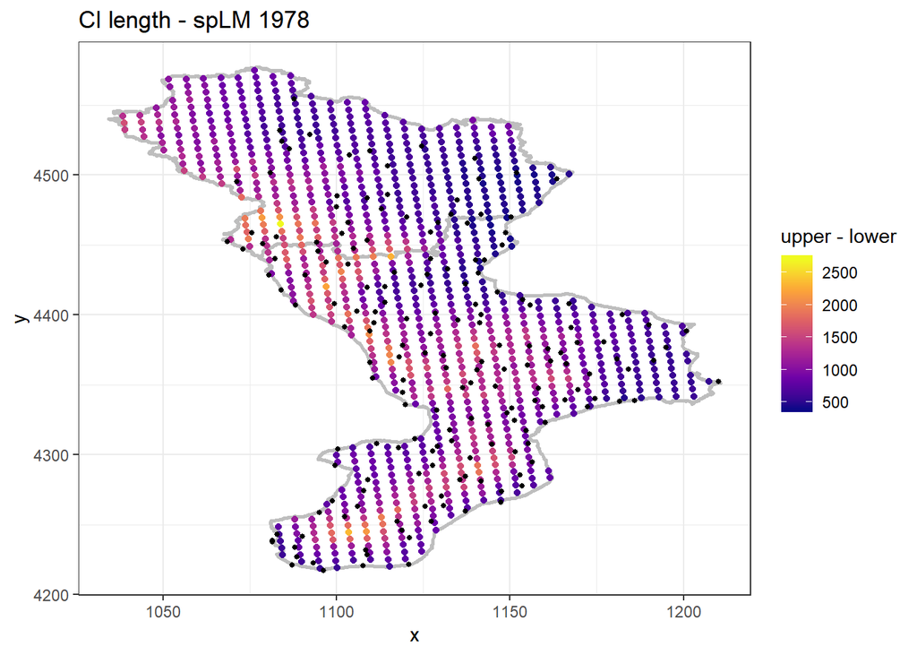

## Confidence Interval and Credibility Interval comparison

The predicted values are similar to each other.

A simple inspection of the confidence interval of the 3 algorithms used to reconstruct the grid of values suggest that the Bayesian Kriging is the best approach. This is due to the narrower confidence intervals provided for the prediction.

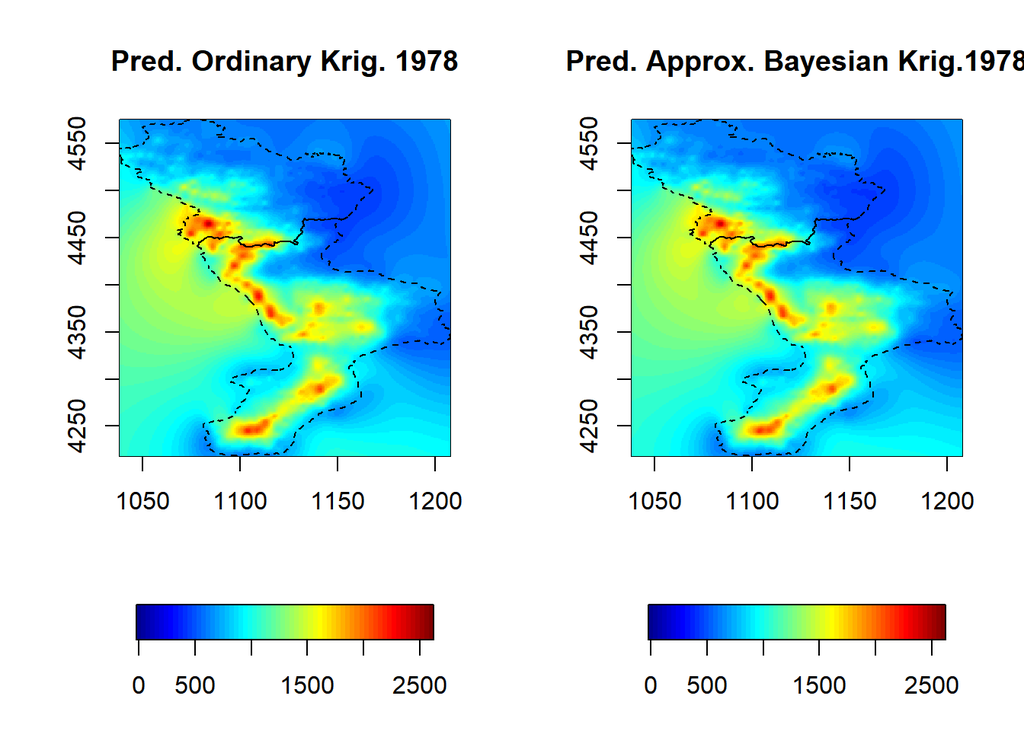

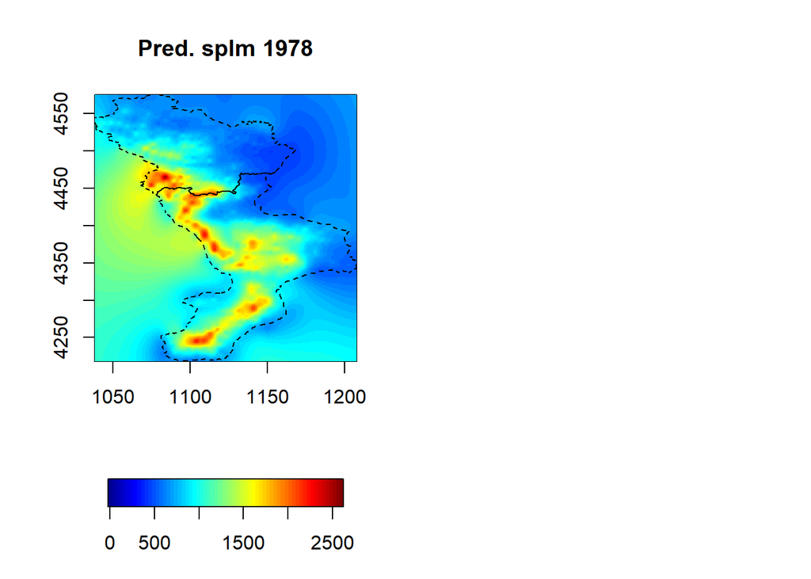

```r
### Prediction summaries
summary(data.1978$value)
```

```
##    Min. 1st Qu.  Median    Mean 3rd Qu.    Max.
##   240.1   701.3   980.9  1034.4  1271.6  2426.2
```

```r
summary(pred.okrig.1978$value)
```

```
##    Min. 1st Qu.  Median    Mean 3rd Qu.    Max.
##   425.0   680.2   935.6  1021.1  1295.4  2478.2
```

```r
summary(pred.krigb.1978$value)
```

```
##    Min. 1st Qu.  Median    Mean 3rd Qu.    Max.
##   417.4   664.0   917.4  1003.4  1274.8  2434.6
```

```r
summary(pred.splm.1978$value)
```

```
##    Min. 1st Qu.  Median    Mean 3rd Qu.    Max.
##   425.3   684.7   931.4  1024.2  1297.8  2506.7
```

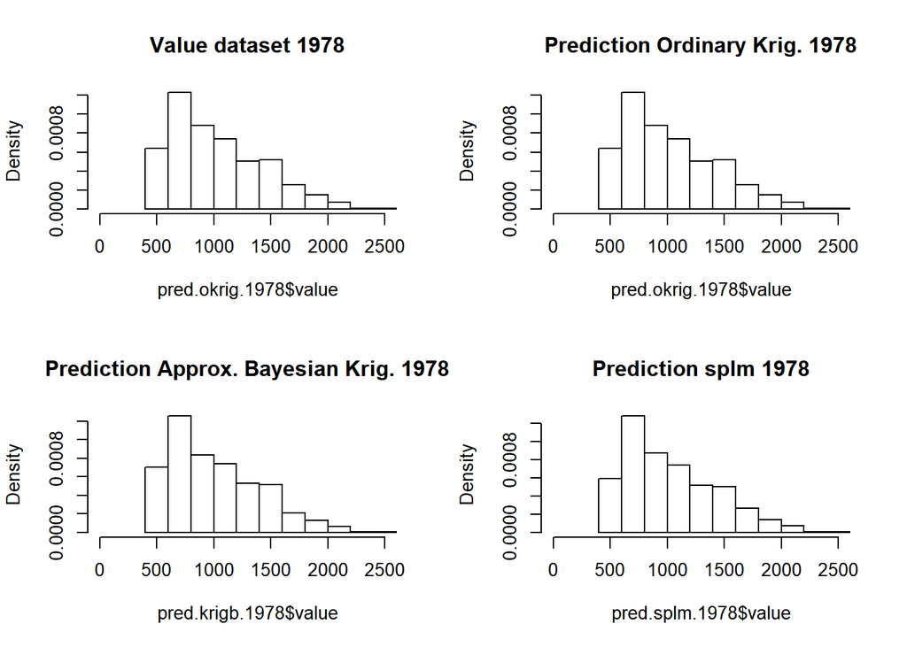

```r
### Prediction Histograms
par(mfrow=c(2,2))
hist(pred.okrig.1978$value, main="", xlim=c(0,2600), prob=T)
title("Value dataset 1978")
hist(pred.okrig.1978$value, main="", xlim=c(0,2600), prob=T)
title("Prediction Ordinary Krig. 1978")
hist(pred.krigb.1978$value, main="", xlim=c(0,2600), prob=T)
title("Prediction Approx. Bayesian Krig. 1978")
hist(pred.splm.1978$value, main="", xlim=c(0,2600), prob=T)
title("Prediction splm 1978")
```

```r
### CI Ordinary Kriging 1978
summary(difference.okrig)
```

```
##    Min. 1st Qu.  Median    Mean 3rd Qu.    Max.
##   364.2   682.8   908.0   977.5  1212.5  2507.0
```

```r
### CI Bayesian Kriging 1978
summary(difference.bayes)
```

```
##    Min. 1st Qu.  Median    Mean 3rd Qu.    Max.
##   227.9   430.8   571.3   622.8   766.3  1636.5
```

```r
### CI spLM 1978
summary(difference.splm)
```

```
##    Min. 1st Qu.  Median    Mean 3rd Qu.    Max.
##   401.4   697.4   928.3   995.6  1235.2  2710.1
```

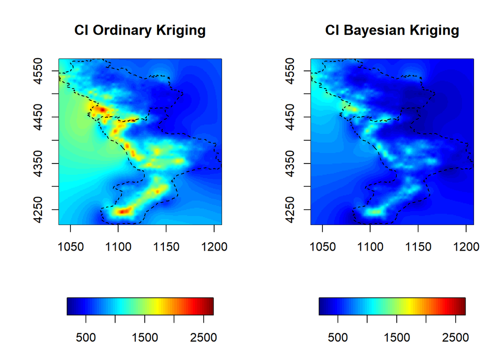

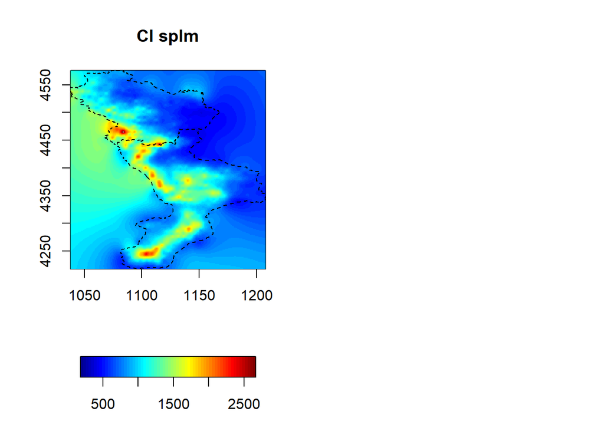

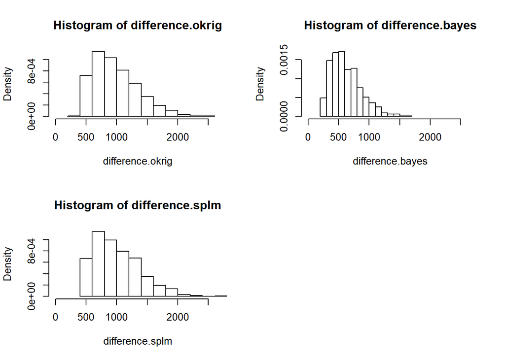

## Year 1981

The exact same analysis will be performed for the year 1981 using only the approximated Bayesian approach.

```r
### dataset 1981
data.1981 = data.frame(dati$XUTM, dati$YUTM, dati$Quota,
                      dati$totanno, dati$anno, dati$Nome_Regione)
colnames(data.1981) = c("x", "y", "z", "value", "year", "regione")

### extracting rows for 1981, Puglia and Calabria
data.1981 = data.1981[which((data.1981[5]==1981) &
                      (data.1981[6]=="Basilicata" | data.1981[6] =="Calabria")),]

### deleting year and region columns, useless for the analysis
data.1981 = data.1981[-c(5,6)]
data.1981[,1:3] = data.1981[,1:3]/1000
row.names(data.1981) = NULL
str(data.1981)
```

```
## 'data.frame':    170 obs. of  4 variables:
##  $ x    : num  1084 1092 1088 1105 1163 ...
##  $ y    : num  4532 4529 4554 4520 4497 ...
##  $ z    : num  0.62 0.568 0.483 0.698 0.003 0.933 0.747 0.7 0.557 0.45 ...
##  $ value: num  326 479 493 429 348 ...
```

```r
### Creating Geodata
geo.data.1981 = as.geodata(obj=data.1981,
                           coords=c(1,2),
                           data.col=4,
                           covar.col=3,
                           covar.names=c("z"))
```

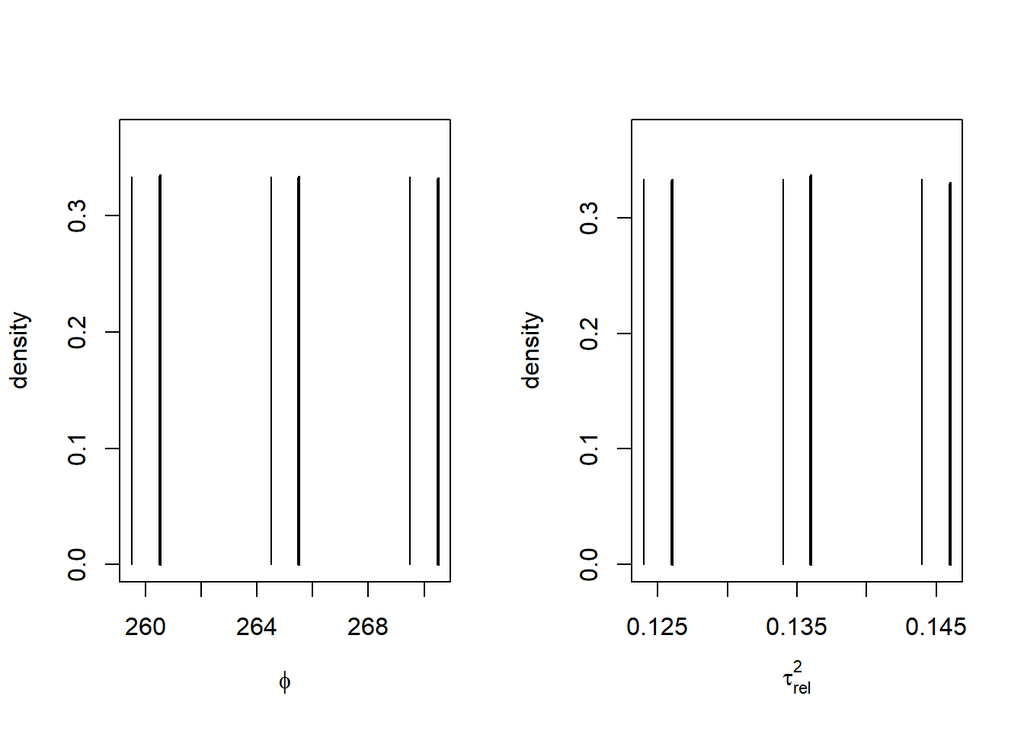

```r
### Covariance function
ctrl = model.control(trend.d=~geo.data.1981$covar$z,
                      trend.l=~grid[,3],
                      cov.model = "spherical",
                      lambda=0)

### Prior distribution for phi and tausq.rel
prior.list = prior.control(phi.prior = "uniform",
                         phi.discrete =seq(260,270,by=5),
                         tausq.rel.prior ="uniform",
                         tausq.rel.discrete = seq(0.125,0.145,by=0.01))

output=output.control(n.posterior=500,
                      messages=F)

### Bayesian Kriging
krig.b = krige.bayes(geo.data.1981,
                     model=ctrl,
                     prior=prior.list,
                     output=output)
par(mfrow=c(1,2))
plot(krig.b, type="h")
```

```r
### Bayes Kriging prediction
output=output.control(n.posterior=500, n.predictive=500,
                      messages=F, quantile=c(0.025,0.975))

krig.b=krige.bayes(geo.data.1981,
                   model=ctrl,
                   prior=prior.list,
                   output=output,
                   locations=grid[,1:2])
```

```r
pred.krigb.1981 = cbind(grid[,1:2],
                    krig.b$predictive$mean,
                    krig.b$predictive$quantiles.simulations$q2.5,
                    krig.b$predictive$quantiles.simulations$q97.5)
colnames(pred.krigb.1981) = c("x","y","value","lower", "upper")

### Data 1981 vs Bayesian Kriging prediction
summary(data.1981$value)
```

```
##    Min. 1st Qu.  Median    Mean 3rd Qu.    Max.
##   199.1   493.1   733.6   826.4  1035.2  2191.0
```

```r
summary(pred.krigb.1981$value)
```

```
##    Min. 1st Qu.  Median    Mean 3rd Qu.    Max.
##   275.9   486.2   695.7   788.4  1040.3  2306.3
```

```r
### 95% Confidence interval Bayesian Kriging
difference.bayes = pred.krigb.1981$upper - pred.krigb.1981$lower
summary(difference.bayes)
```

```
##    Min. 1st Qu.  Median    Mean 3rd Qu.    Max.
##   175.1   368.1   525.6   591.9   760.0  1958.2
```

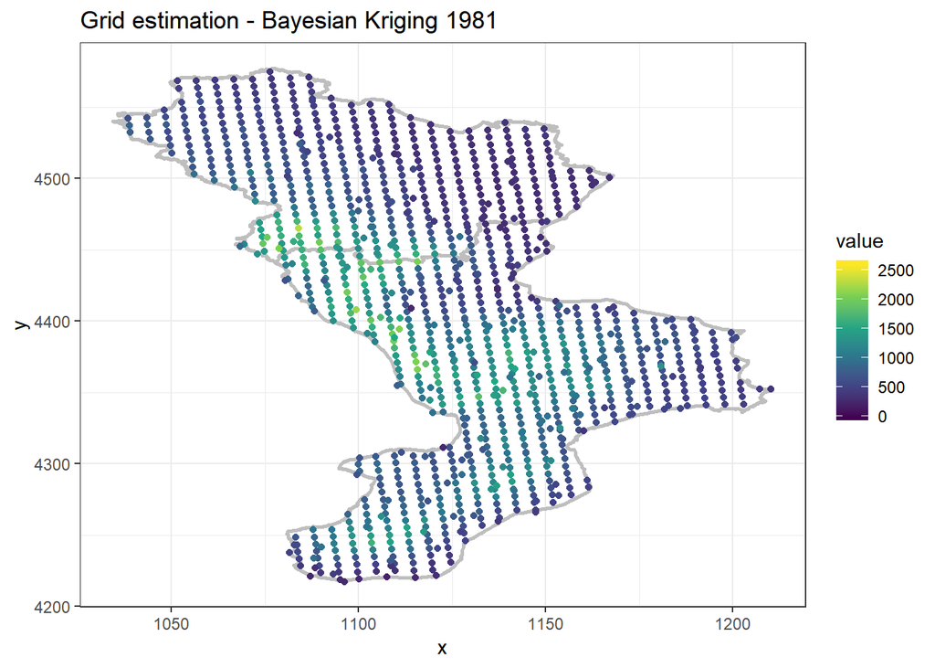

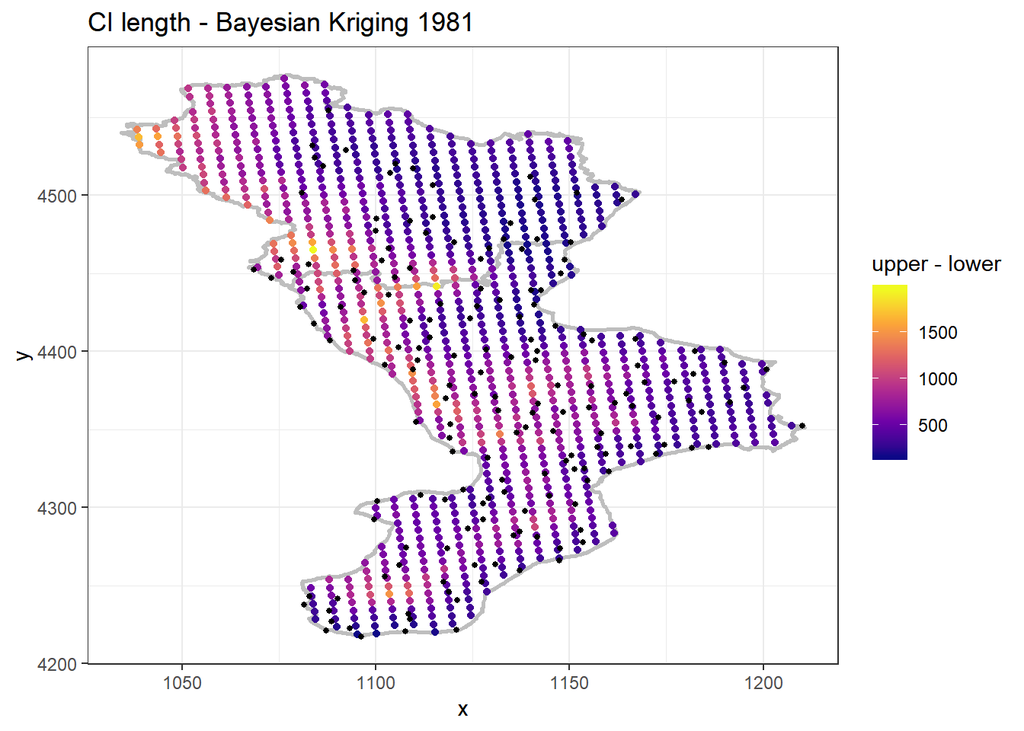

## Comparison between 1978 and 1981

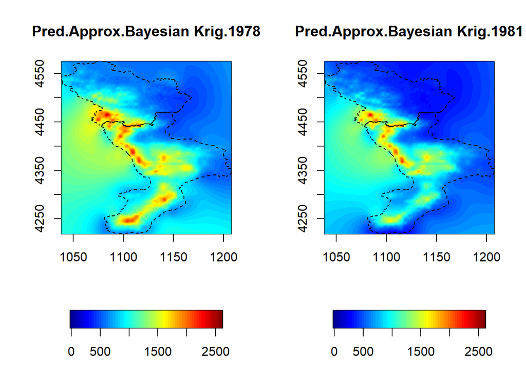

```r
### Prediction Surface
par(mfrow=c(1,2))
surf <- mba.surf(cbind(grid[,1:2], pred.krigb.1978$value),
                 no.X=300, no.Y=300, extend=T)$xyz.est
image.plot(surf, main="Pred.Approx.Bayesian Krig.1978", zlim=c(0,2600),
           horizontal=T)
lines(calabria, lty=2)
lines(basilicata, lty=2)

surf <- mba.surf(cbind(grid[,1:2], pred.krigb.1981$value),
                 no.X=300, no.Y=300, extend=T)$xyz.est
image.plot(surf, main="Pred.Approx.Bayesian Krig.1981", zlim=c(0,2600),
           horizontal=T)
lines(calabria, lty=2)
lines(basilicata, lty=2)
```

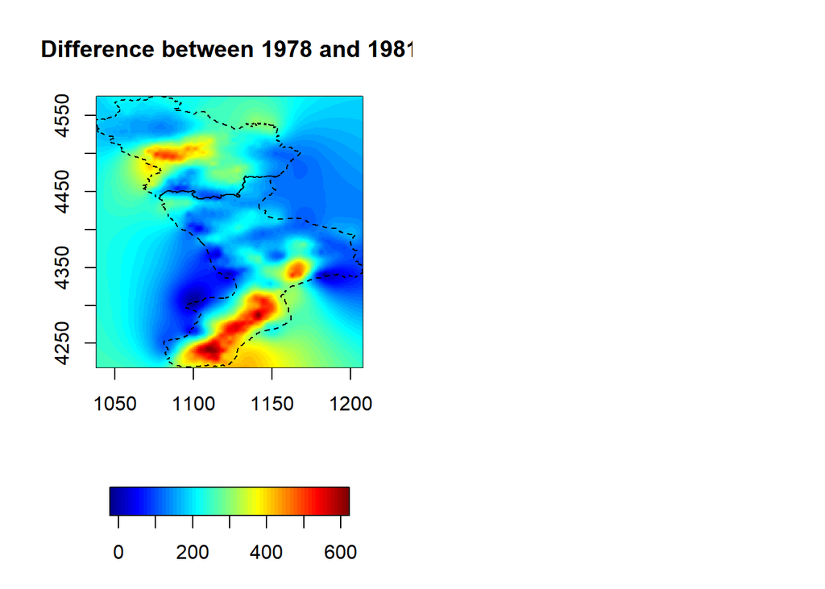

```r
surf <- mba.surf(cbind(grid[,1:2], pred.okrig.1978$value-pred.krigb.1981$value),
                 no.X=300, no.Y=300, extend=T)$xyz.est
image.plot(surf, main="Difference between 1978 and 1981",
           horizontal=T)
lines(calabria, lty=2)
lines(basilicata, lty=2)
```